# Cluster Report: GoiEner PRE, 20 clusters

Universidad de Deusto (carlos.quesada@deusto.es)

2022-02-21 12:25:07

#### List of abbreviations

##### Sets of features

- **sAggrDRM**: seasonal aggregates v2.0 (day-referenced mean)
- **sAggrP6**: seasonal aggregates v3.0 (6-period time division)

##### Datasets

- **goi**: GoiEner (including Megara and La Corriente) [ES]

##### Clustering methods

- **som**: self-organizing maps

## sAggrDRM > goi > som

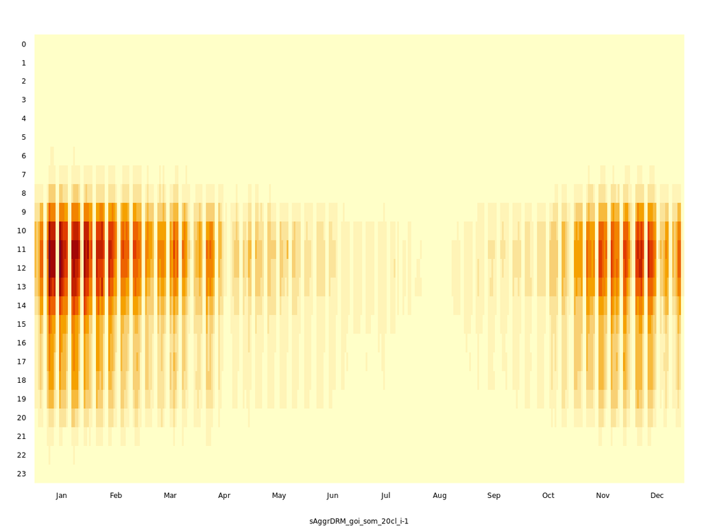

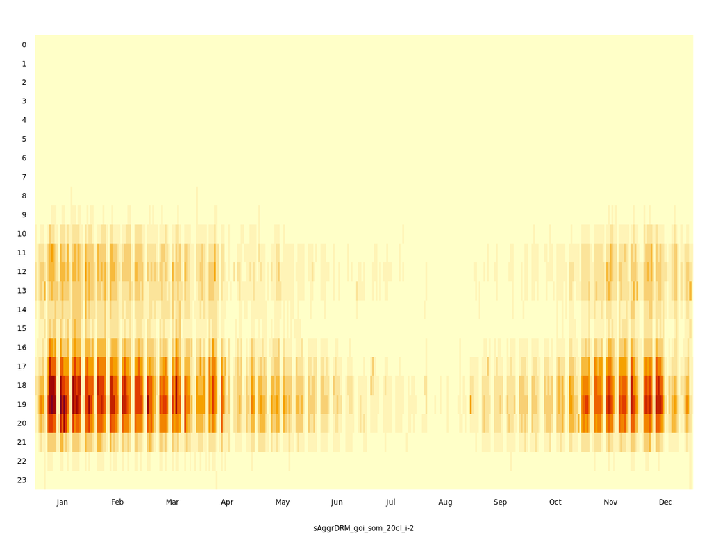

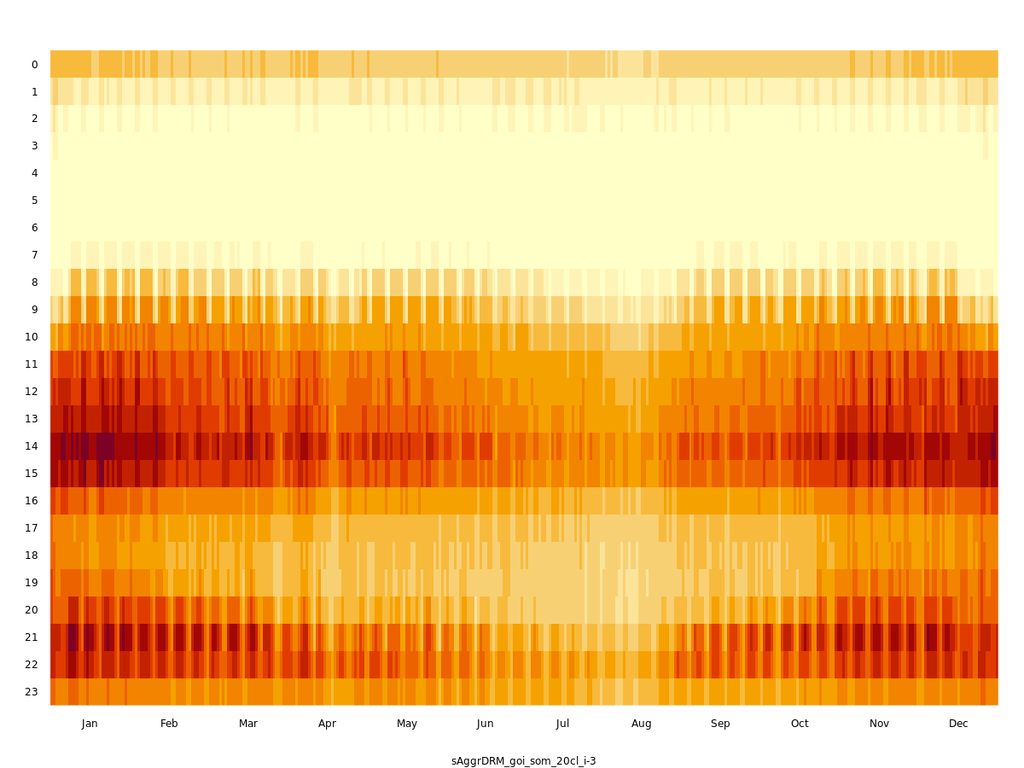

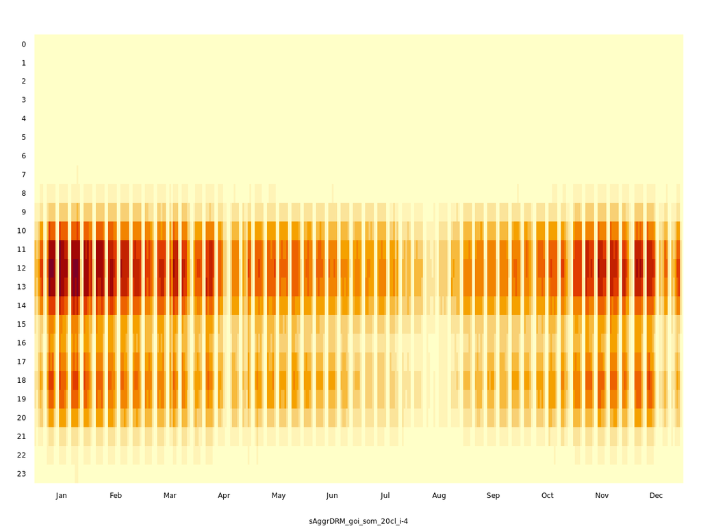

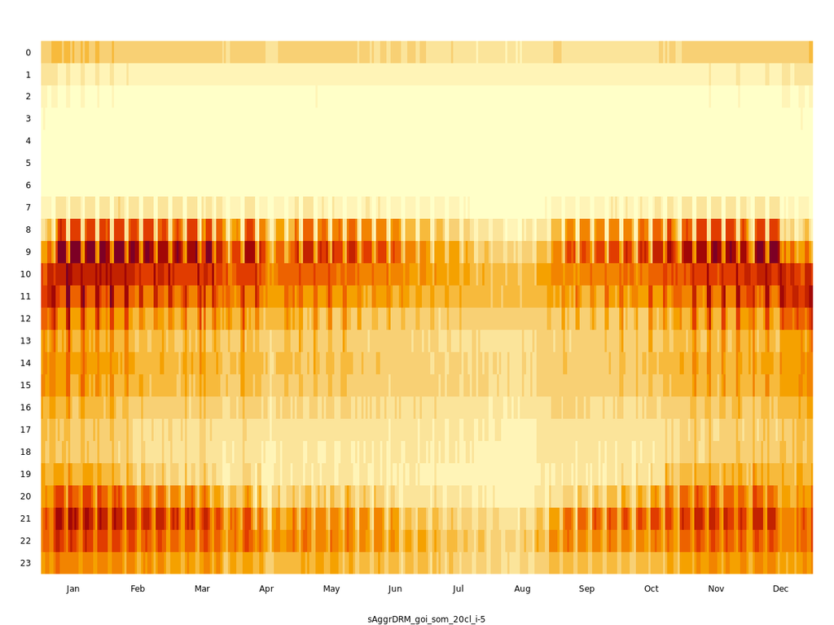

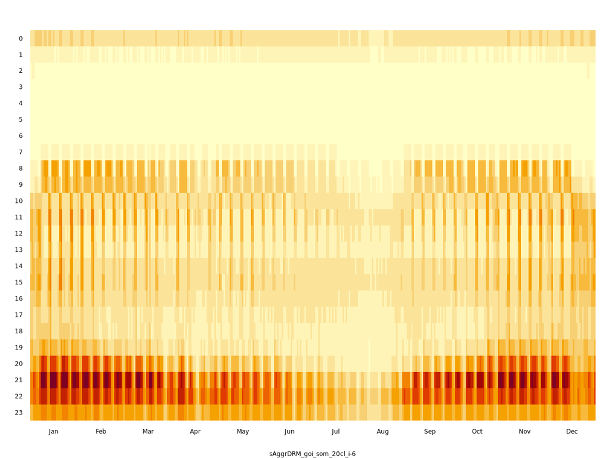

sAggrDRM > goi > som > #1

149 TS (1.2%)

sAggrDRM > goi > som > #2

82 TS (0.7%)

sAggrDRM > goi > som > #3

1320 TS (11.1%)

sAggrDRM > goi > som > #4

392 TS (3.3%)

sAggrDRM > goi > som > #5

975 TS (8.2%)

sAggrDRM > goi > som > #6

1588 TS (13.3%)

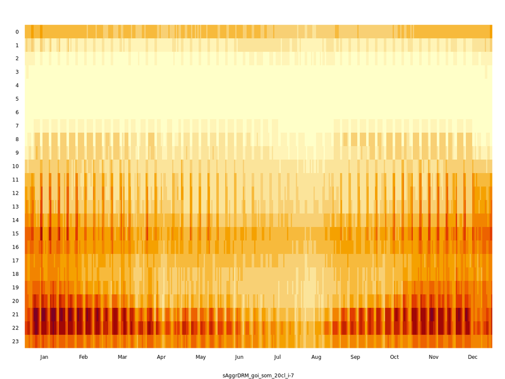

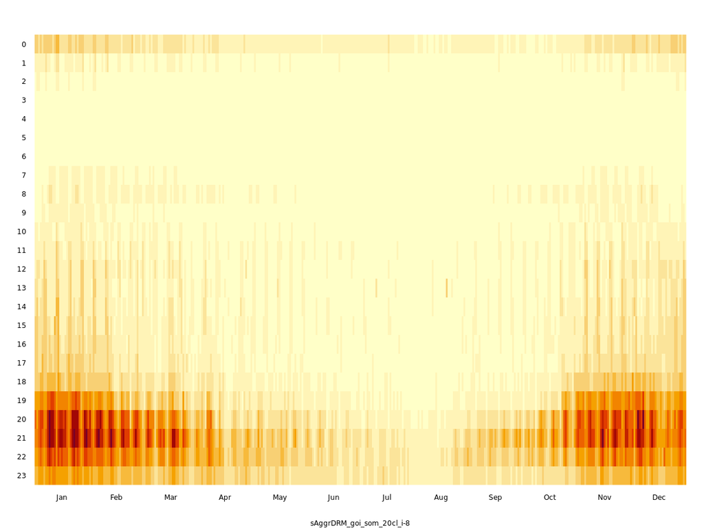

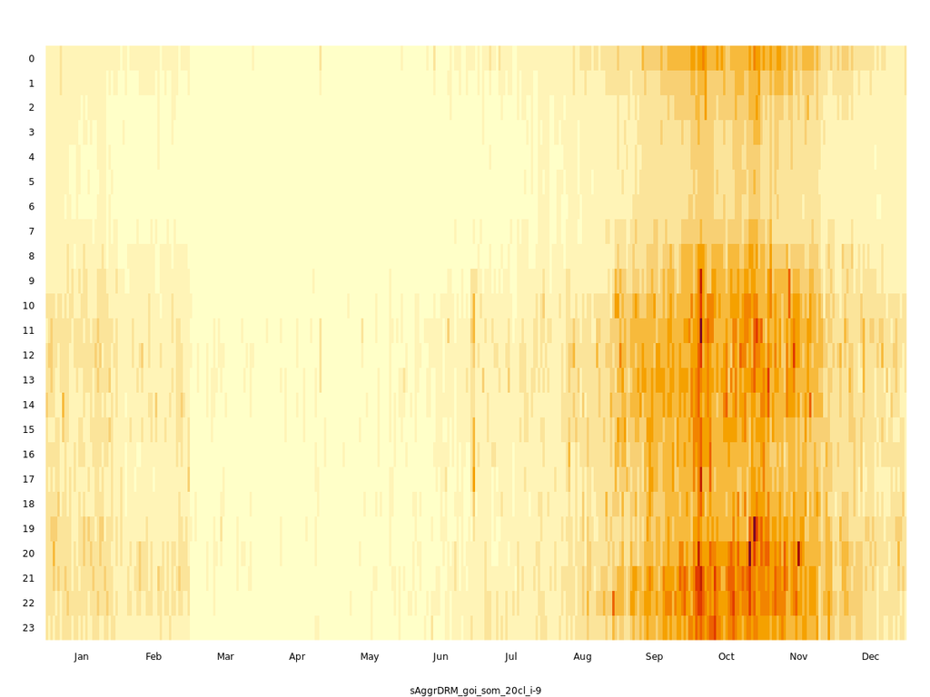

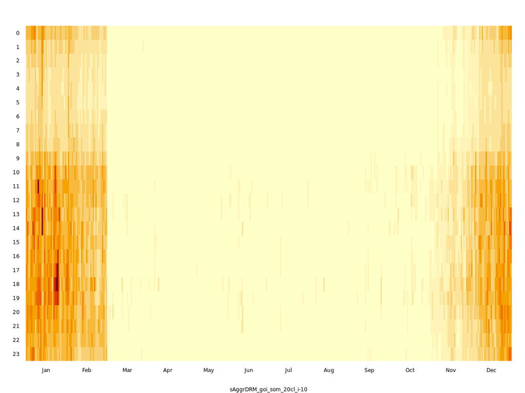

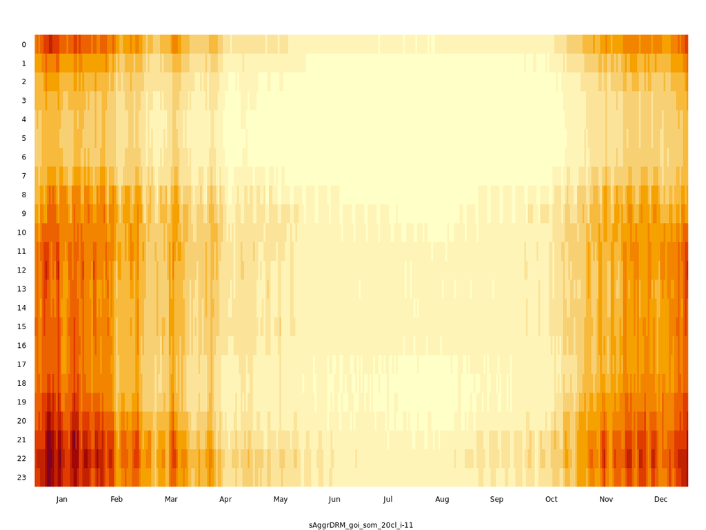

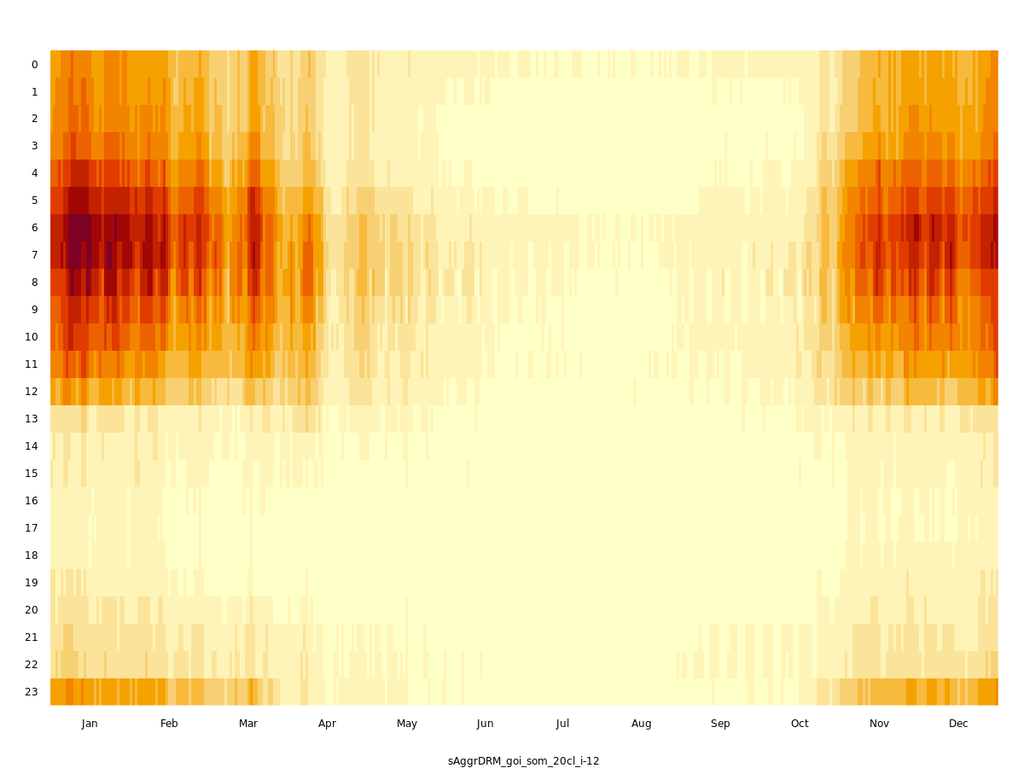

sAggrDRM > goi > som > #7

1284 TS (10.8%)

sAggrDRM > goi > som > #8

116 TS (1%)

sAggrDRM > goi > som > #9

82 TS (0.7%)

sAggrDRM > goi > som > #10

63 TS (0.5%)

sAggrDRM > goi > som > #11

573 TS (4.8%)

sAggrDRM > goi > som > #12

140 TS (1.2%)

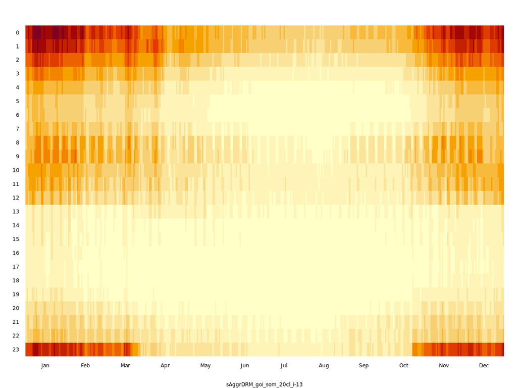

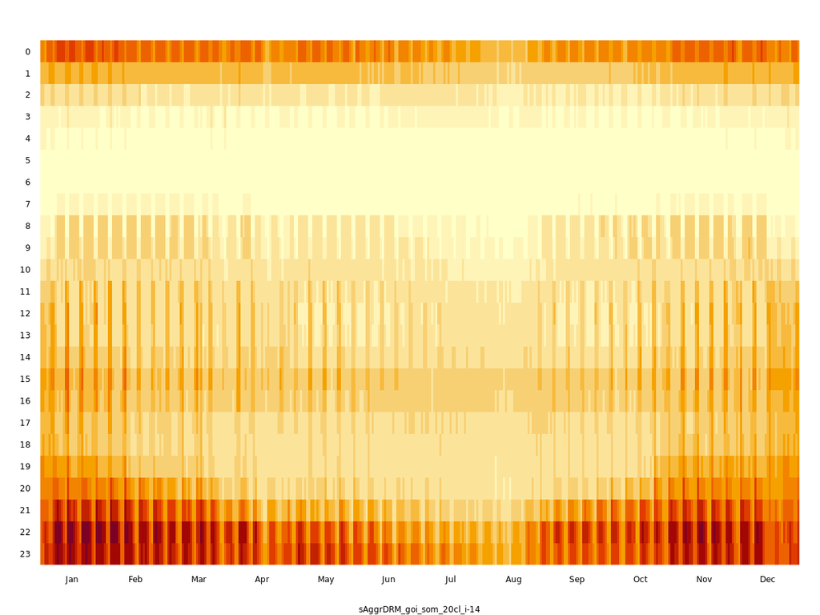

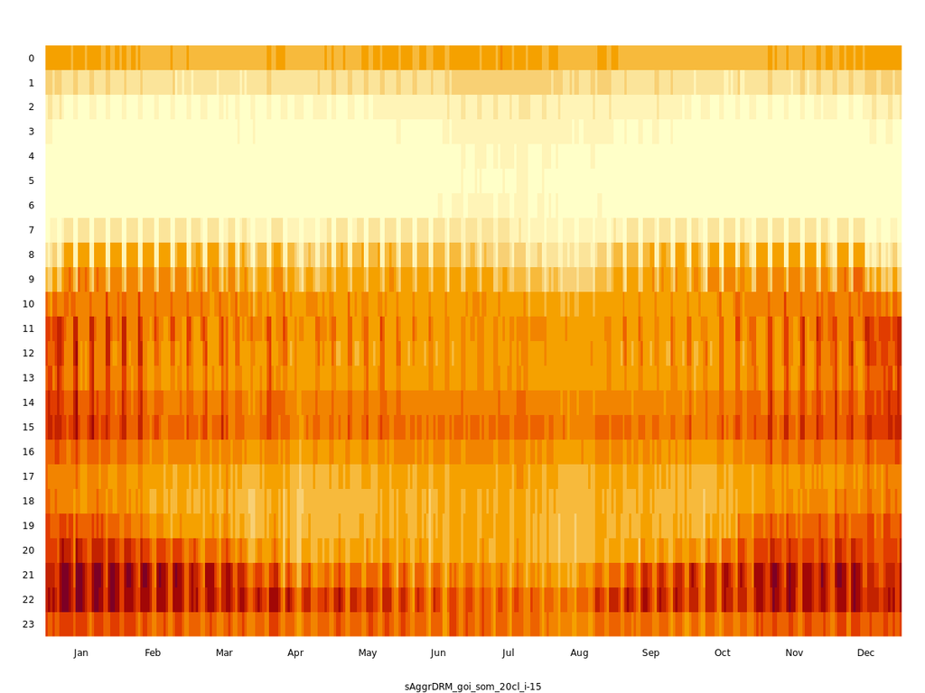

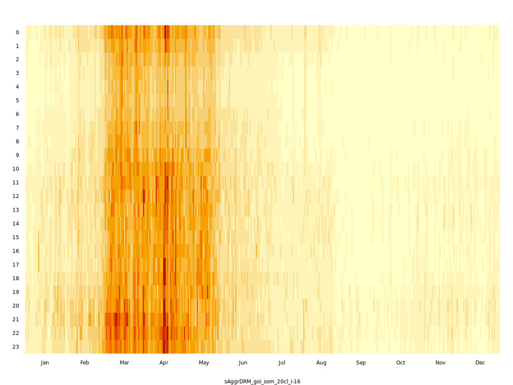

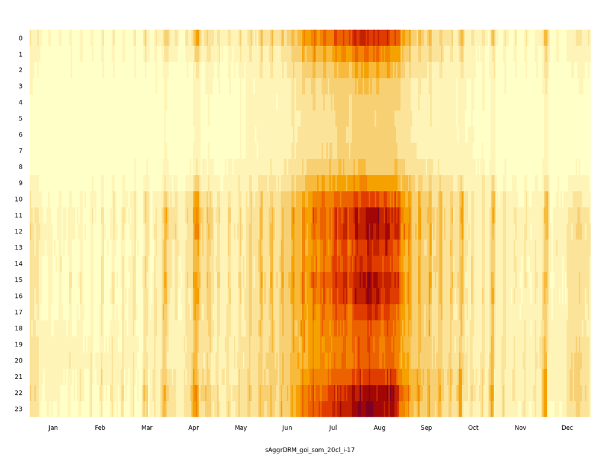

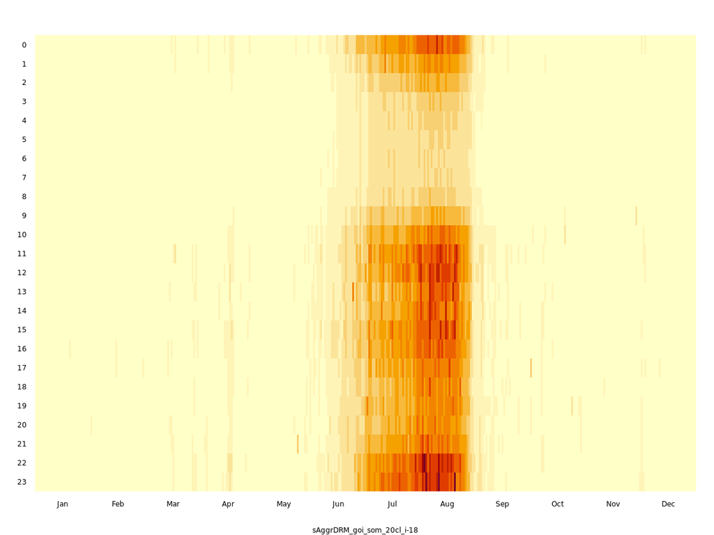

sAggrDRM > goi > som > #13

158 TS (1.3%)

sAggrDRM > goi > som > #14

1363 TS (11.4%)

sAggrDRM > goi > som > #15

1802 TS (15.1%)

sAggrDRM > goi > som > #16

79 TS (0.7%)

sAggrDRM > goi > som > #17

355 TS (3%)

sAggrDRM > goi > som > #18

92 TS (0.8%)

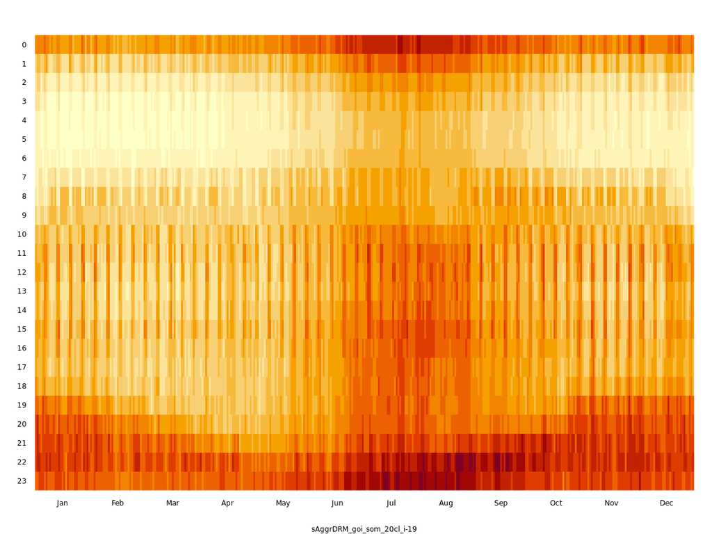

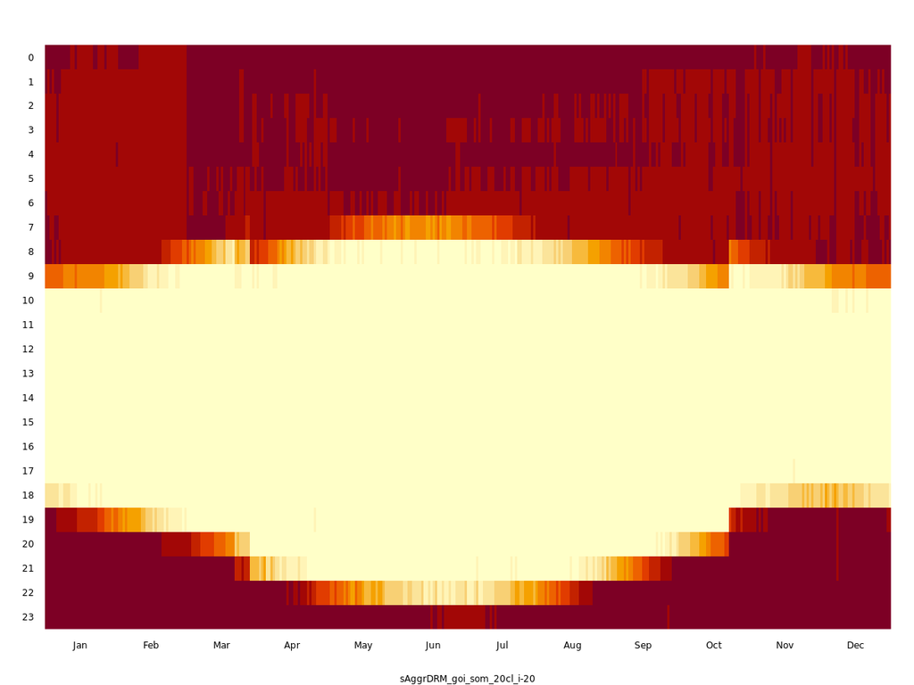

sAggrDRM > goi > som > #19

1092 TS (9.1%)

sAggrDRM > goi > som > #20

238 TS (2%)